# Storm Data Analysis

Devender R. Gollapally

## Synopsis

Utilizing the storm dataset provided by The U.S National Oceanic and Atmospheric Administration (NOAA) we try to answer *two* basic questions about severe weather events namely:

1. Across the US, which types of events are the most harmful with respect to population health ?
2. Across the US, which types of events have the greatest economic consequences ?

Our results shows that the most harmful event type for population health is Tornados and the eventy type with the greatest economic consequences is flodding.

The code used to analyze the data and produce this report is available on GitHub at this [repository](https://github.com/devender/research-project-2).

## Data Processing

For this research we download the dataset from [here](https://d396qusza40orc.cloudfront.net/repdata%2Fdata%2FStormData.csv.bz2).

```r
if(!file.exists("data/StormData.csv")){

    if(!file.exists("data/StormData.csv.bz2")){
        flog.info("downloading dataset")
        url<-"https://d396qusza40orc.cloudfront.net/repdata%2Fdata%2FStormData.csv.bz2"
        download.file(url,"data/StormData.csv.bz2",method="curl")
    }

    bunzip2("data/StormData.csv.bz2", destname="data/StormData.csv")
}
```

The unzipped file StormData.csv has more than 30 columns but for this analysis we require only a few that we read into memory.

```r
storm_data <- fread("data/StormData.csv",sep=",",header=TRUE,select=c("EVTYPE",
"FATALITIES","INJURIES","PROPDMG","PROPDMGEXP","CROPDMG","CROPDMGEXP"))
```

Lets factorize the event type and take a look at data.

```r
storm_data <- transform(storm_data,EVTYPE = factor(EVTYPE))
str(storm_data)
```

```
## Classes 'data.table' and 'data.frame':   902297 obs. of  7 variables:
##  $ EVTYPE    : Factor w/ 985 levels "   HIGH SURF ADVISORY",..: 834 834 834 834 834 834 834 834 834 834 ...
##  $ FATALITIES: num  0 0 0 0 0 0 0 0 1 0 ...
##  $ INJURIES  : num  15 0 2 2 2 6 1 0 14 0 ...
##  $ PROPDMG   : num  25 2.5 25 2.5 2.5 2.5 2.5 2.5 25 25 ...
##  $ PROPDMGEXP: chr  "K" "K" "K" "K" ...
##  $ CROPDMG   : num  0 0 0 0 0 0 0 0 0 0 ...
##  $ CROPDMGEXP: chr  "" "" "" "" ...
##  - attr(*, ".internal.selfref")=<externalptr>
```

### Preparing the Property Damage and Crop Damage data.

Both the property damage and crop damage is represented as two fields the base and the exponent, we need to transform this into a single field so that we can do proper comparisons.

Property Damage Exponent

```r
unique(storm_data$PROPDMGEXP)
```

```
##  [1] "K" "M" ""  "B" "m" "+" "0" "5" "6" "?" "4" "2" "3" "h" "7" "H" "-"
## [18] "1" "8"
```

Crop Damage Exponent

```r
unique(storm_data$CROPDMGEXP)
```

```
## [1] ""  "M" "K" "m" "B" "?" "0" "k" "2"
```

#### Function to expand the exponent

```r
expand_expo<-function(char){
    if(char == "M" | char == "m"){
        return(1e+06)
    }else if(char == "K" | char == "k"){
        return(1e+03)
    }else if(char=="B" | char == "b"){
        return(1e+09)
    }else if(char=="H" | char == "h"){
        return(1e+02)
    }else if(char=="" | char=="+" | char=="?" | char == "-"){
        return(1)
    }else{
        return(as.numeric(char))
    }
}
#creating a vectorized function
v_expand_expo<-Vectorize(expand_expo, SIMPLIFY = TRUE)
```

#### Transform the data set

```r
storm_data<-storm_data %>%
    mutate(cropDamage = CROPDMG * v_expand_expo(CROPDMGEXP)) %>%
    mutate(propDamage = PROPDMG * v_expand_expo(PROPDMGEXP))
```

## Results

### Across the United States, which types of events are most harmful with respect to population health?

```r
pop_health<- storm_data %>%
    group_by(EVTYPE) %>%
    summarize(Injuries = log(sum(INJURIES)),
              Fatalities = log(sum(FATALITIES)),
              total = log(sum(INJURIES)) + log(sum(FATALITIES))) %>%
    arrange(desc(total)) %>%
    top_n(10)
```

Let go ahead and plot the above data using lattice and see what we get:

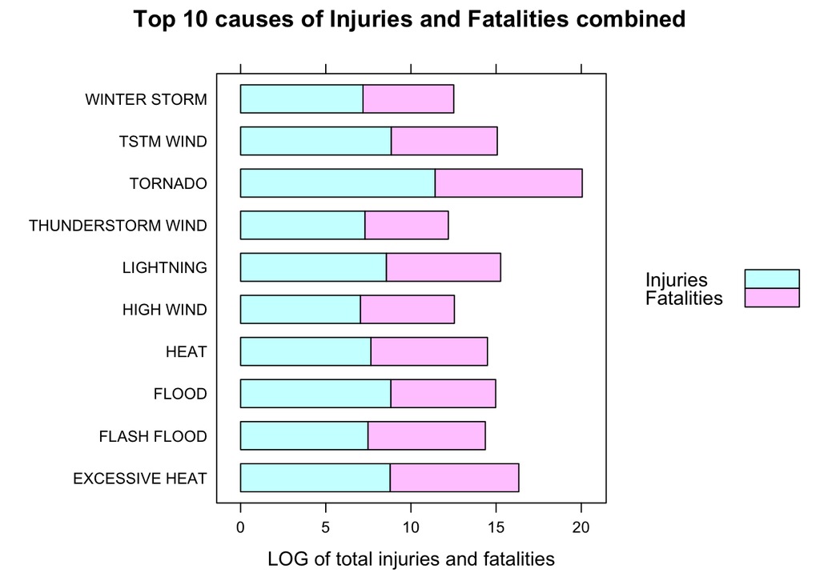

```r
barchart(EVTYPE ~ Injuries + Fatalities,
         data = pop_health,
         stack = TRUE,
         auto.key = list(space="right"),
         main = list(label="Top 10 causes of Injuries and Fatalities combined"),
         xlab = c("LOG of total injuries and fatalities"))
```

### Across the United States, which types of events have the greatest economic consequences?

To find this we will group the observations by event type and get the sum of all property and crop dameges. We further limit it to the top 10 most harmful event types.

```r
economy<-storm_data %>%
    group_by(EVTYPE) %>%
    summarise(PropertyDamage = sum(propDamage),
              CropDamage = sum(cropDamage),
              total = sum(propDamage)+sum(cropDamage)) %>%
    arrange(desc(total)) %>%
    top_n(10)
```

Let go ahead and plot the above data using lattice and see what we get:

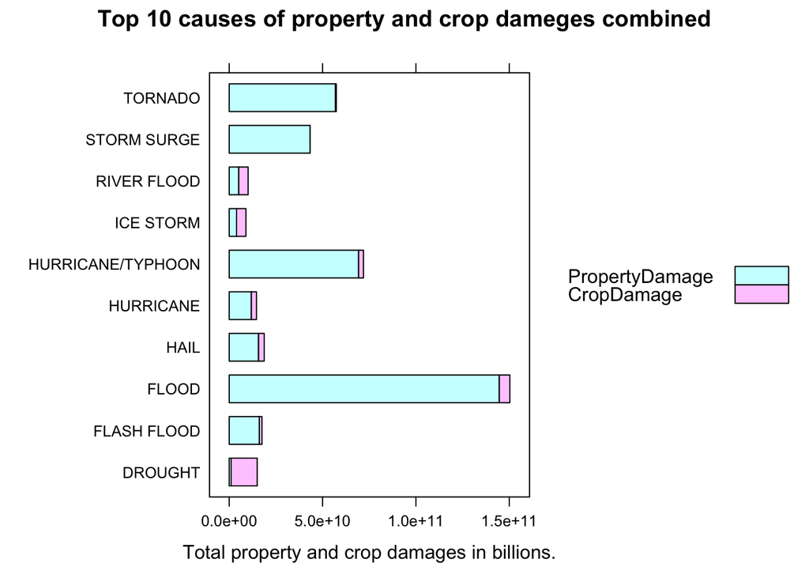

```r
barchart(EVTYPE ~ PropertyDamage + CropDamage,
         data = economy,
         stack = TRUE,
         auto.key = list(space="right"),
         main = list(label="Top 10 causes of property and crop dameges combined"),
         xlab = c("Total property and crop damages in billions."))
```